# wolf-sheep

Andres Baeza and Felix John

February 17, 2017

# Experiment 1

experiment setup: 100 repetitions, 500 ticks [“sheep-gain-from-food” [2 1 20]][“wolf-gain-from-food” [10 0.5 30]]

## read the data from netlogo

```r
require(ggplot2)
dynamicCsv <- getURL("https://dev.commons.asu.edu/data/abmclub/wolf-sheep/dynamic.csv")
E1<-read.csv(textConnection(dynamicCsv), header = TRUE,skip = 6,comment.char ="#")
names(E1)[c(1, 12:17)] <- c("runID", "time", "N_wolves", "N_sheep", "grass",
                                   "energy_wolves", "energy_sheep")

#read a source code for a function that plots multiple ggplots in one layer
source("multiplot_function.R")
```

## scatter plots

here we plot the final population size of wolves (y-axis) vs. the level of energy they gain from sheeps (x axis). We repeat this plot procedure for three values of the energy sheeps gain from grass (4,5,6)

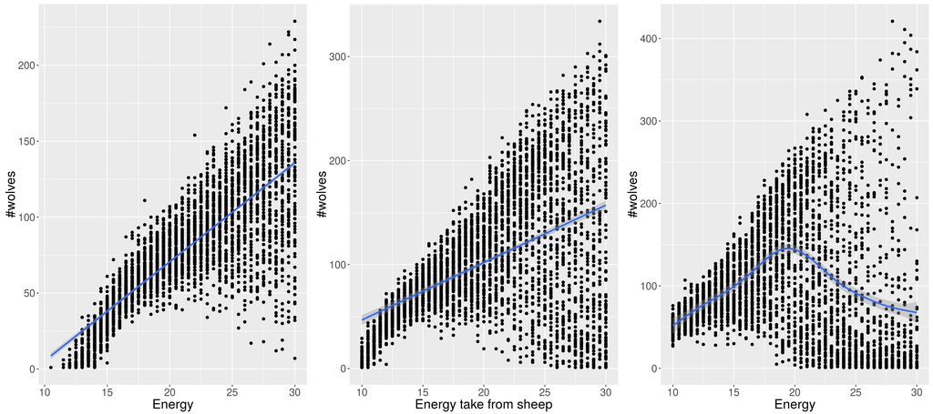

```r
P1=ggplot(subset(E1,sheep.gain.from.food == 4 & N_wolves >0),aes(x=wolf.gain.from.food,y=N_wolves))+
  geom_point()+
   labs(x = "Energy", y="#wolves")+
theme(text = element_text(size=18))+
    geom_smooth(span=1,method = "lm")
P2=ggplot(subset(E1,sheep.gain.from.food == 5 & N_wolves >0),aes(x=wolf.gain.from.food,y=N_wolves))+
  geom_point()+
   labs(x = "Energy take from sheep", y="#wolves")+
theme(text = element_text(size=18))+
    geom_smooth(method = "lm", level=0.99)

P3=ggplot(subset(E1,sheep.gain.from.food == 6& N_wolves >0),aes(x=wolf.gain.from.food,y=N_wolves))+
  geom_point()+
   labs(x = "Energy", y="#wolves")+
theme(text = element_text(size=18))+
    geom_smooth()

multiplot(P1, P2,P3,cols=3)
```

## “heat maps”

A raster is contructed by filling each pixel represent a combination of parameter values (x=energy wolves gain from sheeps; y= energey sheeps gain from grass) The color of the pixel represents the final population of wolves (panel a) and sheeps (panel b)

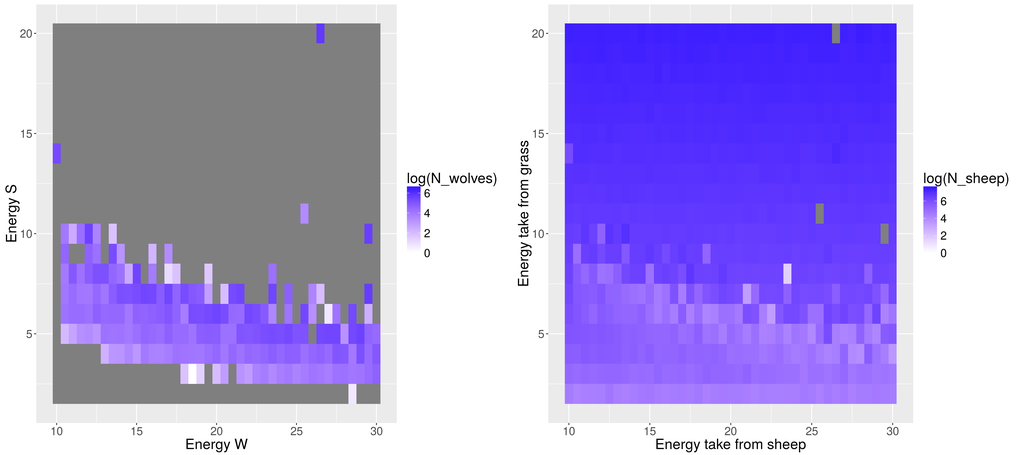

```r
P2=ggplot(E1,aes(x=wolf.gain.from.food, y=sheep.gain.from.food,fill=log(N_wolves)))+
  geom_raster()+
   labs(x = "Energy W", y="Energy S")+
theme(text = element_text(size=18))+
  scale_fill_gradient2(low='white', high='blue')


P3=ggplot(E1,aes(x=wolf.gain.from.food, y=sheep.gain.from.food,fill=log(N_sheep)))+
  geom_raster()+
   labs(x = "Energy take from sheep", y="Energy take from grass")+
theme(text = element_text(size=18))+
  scale_fill_gradient2(low='white', high='blue')
multiplot(P2,P3,cols=2)
```

## Frequency/density plots

these plots display the frequency of simulations that generate a particualr population size

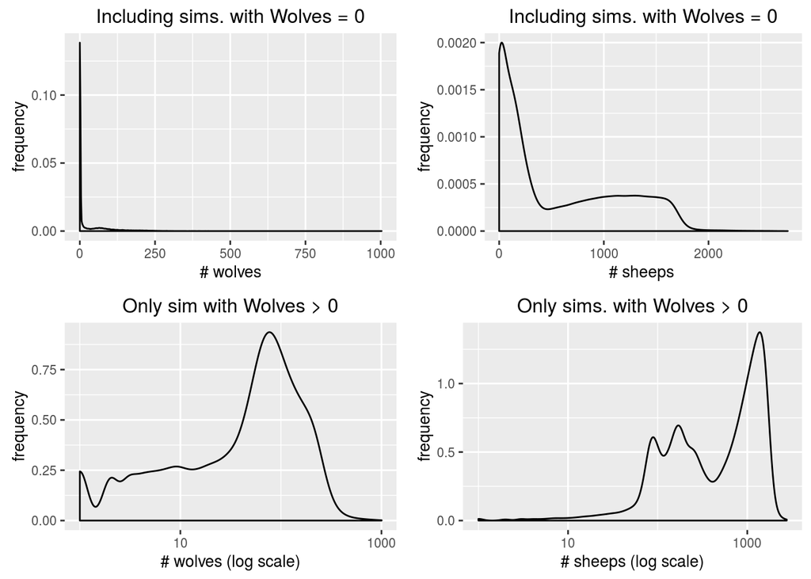

```r
P1=ggplot(E1,aes(x=N_wolves))+
  geom_density()+
   labs(x = "# wolves", y="frequency",title="Including sims. with Wolves = 0")+
theme(text = element_text(size=10))

P2=ggplot(E1,aes(x=N_wolves))+
  geom_density()+
   labs(x = "# wolves (log scale)", y="frequency")+
theme(text = element_text(size=10))+
  scale_x_log10()+
  ggtitle("Only sim with Wolves > 0")

P3=ggplot(E1,aes(x=N_sheep))+
  geom_density()+
   labs(x = "# sheeps ", y="frequency",title="Including sims. with Wolves = 0")+
theme(text = element_text(size=10))

P4=ggplot(E1,aes(x=N_sheep))+
  geom_density()+
   labs(x = "# sheeps (log scale)", y="frequency")+
theme(text = element_text(size=10))+
  scale_x_log10()+
  ggtitle("Only sims. with Wolves > 0")


multiplot(P1, P2,P3,P4,cols=2)
```

# Experiment 2: Time series

## Experiment setup:

- 10 repetitions, 500 ticks (stop when wolves go extinct)
- “initial.number.wolves” [1 10 250]
- “initial-number-sheep” [1 10 250]
- variables are measured at every time step

## Read in and reformat the data

Read the data from the file and give the output variables more intuitive names:

```r
staticCsv <- getURL("https://dev.commons.asu.edu/data/abmclub/wolf-sheep/static.csv")
data.exp2 <- read.csv(textConnection(staticCsv), skip = 6, header = T)

names(data.exp2)[c(1, 12:17)] <- c("runID", "time", "N_wolves", "N_sheep", "grass",
                                   "energy_wolves", "energy_sheep")
```

Calculate the means across the repitions:

```r
library(dplyr)
means <- data.exp2 %>%
  arrange(time) %>%
  group_by(initial.number.sheep, initial.number.wolves, time) %>%
  summarise(N_wolves = mean(N_wolves),
            N_sheep = mean(N_sheep),
            grass = mean(grass)) %>%
  mutate(ID = paste("s", initial.number.sheep, "w", initial.number.wolves, sep = "_"))
```

The pipe operator (`%>%`) is part of the `dplyr` package and lets you connect different operations that are carried out sequentially. Moreover, it helps you keep your code tidy. `group_by` and `summarise` first split up the dataset and then calculate some summary statistics. `mutate` is used to create a new variable (it can also overwrite existing variables). The ID is just needed for internal purposes in the graphs below (to tell R which values belong together)

## Plot time series

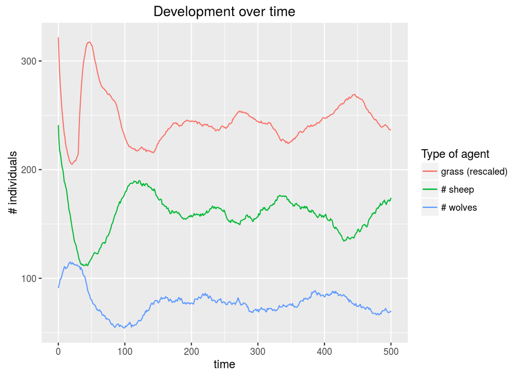

```r
require(ggplot2)
require(dplyr)
init_sheep <- 241
init_wolves <- 91
means %>%
  filter(initial.number.sheep == init_sheep & initial.number.wolves == init_wolves) %>%
  ggplot(aes(x = time)) +
  geom_line(aes(y = grass/4, colour = "grass (rescaled)")) +
  geom_line(aes(y = N_wolves, colour = "# wolves")) +
  geom_line(aes(y = N_sheep, colour = "# sheep")) +
  labs(x = "time", y = "# individuals", colour = "Type of agent", title = "Development over time")
```

Here, we first select the initial conditions we want to use. Setting colour to a character value assigns a standard colour to the graph, but prints that character value in the legend.

## Plot phase plane

Plot all repetitions and their mean for one initial condition:

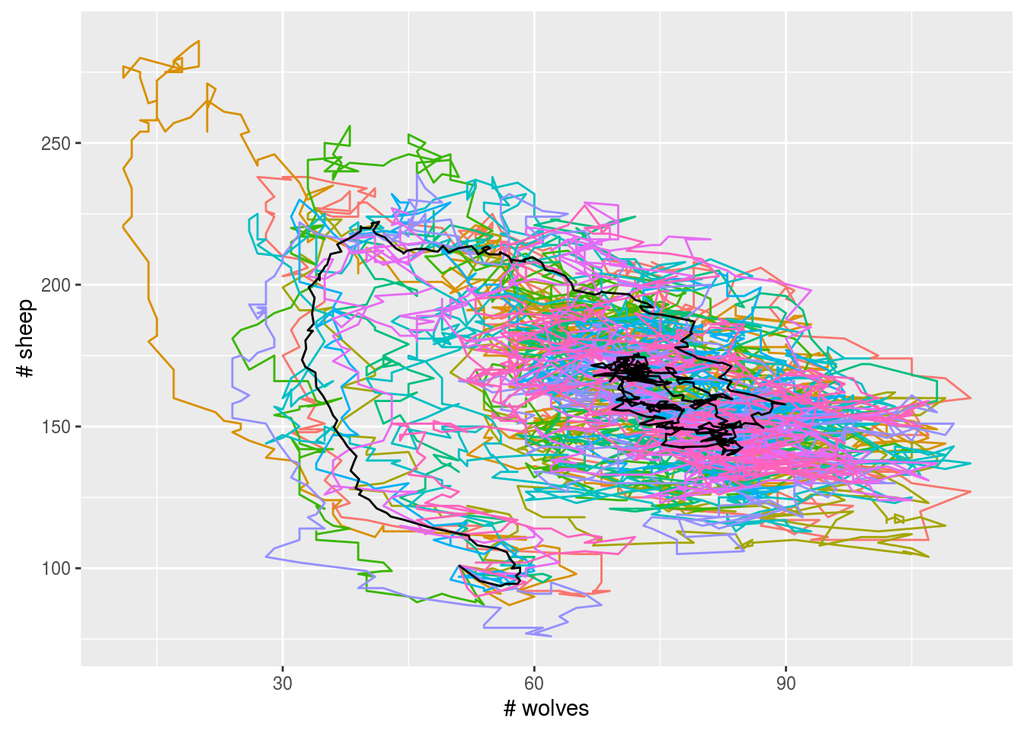

```r
library(ggplot2)
init_sheep <- 101
init_wolves <- 51
data.exp2 %>%
  filter(initial.number.sheep == init_sheep & initial.number.wolves == init_wolves) %>%
  ggplot(aes(x = N_wolves, y = N_sheep)) +
  geom_path(aes(colour = factor(runID)), show.legend = F) +
  geom_path(data = filter(means, initial.number.sheep == init_sheep & initial.number.wolves == init_wolves),
            aes(x = N_wolves, y = N_sheep), colour = "black") +
  labs(x = "# wolves", y = "# sheep")
```

The coloured lines depict the individual runs, the black line depicts the mean.

*Note:* `geom_path` connects the observations in the order in which they appear in the data. Therefore, you have to make sure that the data is ordered correctly. We did that with the `arrange` command in the previous code chunk.

Plot the means of different initial conditions

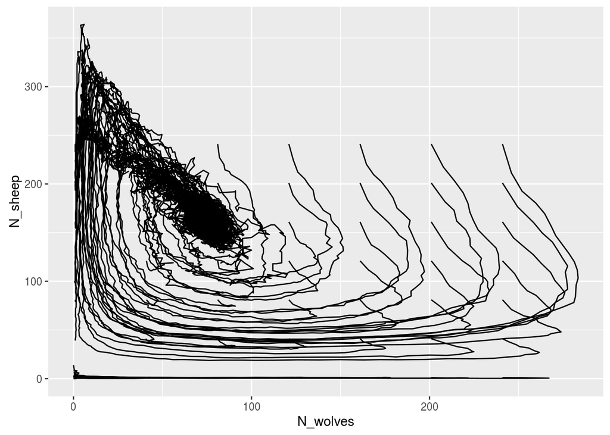

```r
init_cond <- c(1, 41, 81, 121, 161, 201, 241)
means %>%
  filter(initial.number.sheep %in% init_cond & initial.number.wolves %in% init_cond) %>%
  ggplot(aes(x = N_wolves, y = N_sheep)) +
  geom_path(aes(group = factor(ID)))
```